# Untitled

2024-10-13

#1) Import the file RegressionData.csv into R using the read.csv command. ## i. Using the results you obtain, present the summary statistics (i.e., mean and standard deviation) of each of the variables in a table, such as the one below.

```r
regression_data <- read.csv("RegressionData.csv")

data_1 <- regression_data %>%
  dplyr::select(MEDHVAL, PCTBACHMOR, PCTVACANT, PCTSINGLES) %>%
  rename(
    MedianHouseValue = MEDHVAL,
    PctBachMore = PCTBACHMOR,
    PctVacant = PCTVACANT,
    PctSingles = PCTSINGLES
  )



# Calculate mean and standard deviation for selected columns
summary_stats <- data_1 %>%
  summarise(across(everything(), list(mean = mean, sd = sd), na.rm = TRUE))
summary_stats_long <- summary_stats %>%
  pivot_longer(cols = everything(), names_to = c("Variable", "Statistic"), names_sep = "_")


# Display the table with kable
kable(summary_stats_long, col.names = c("Variable", "Statistic", "Value"),
      caption = "Mean and Standard Deviation of Selected Variables")
```

Mean and Standard Deviation of Selected Variables

| Variable | Statistic | Value |
| --- | --- | --- |
| MedianHouseValue | mean | 66287.733139 |
| MedianHouseValue | sd | 60006.075990 |
| PctBachMore | mean | 16.081372 |
| PctBachMore | sd | 17.769558 |
| PctVacant | mean | 11.288529 |
| PctVacant | sd | 9.628472 |
| PctSingles | mean | 9.226473 |
| PctSingles | sd | 13.249250 |

##ii. Also, observe from the histograms that none of the variables looks normal

### a. Remember: If the variable has any zero values, use the log(1+[VAR]) transformation instead of the log([VAR]) transformation.

```r
reg_data <- regression_data %>%

  mutate(
    LNMEDHVAL = log(1+MEDHVAL),
    LNPCBACHMORE = log(1+PCTBACHMOR),
    LNNBELPOV100 = log(1+NBELPOV100),
    LNPCTVACANT = log(1+PCTVACANT),
    LNPCTSINGLES = log(1+PCTSINGLES)

  )

#names(reg_data)
```

### b. In your report, you will be asked to present histograms of the original and transformed variables

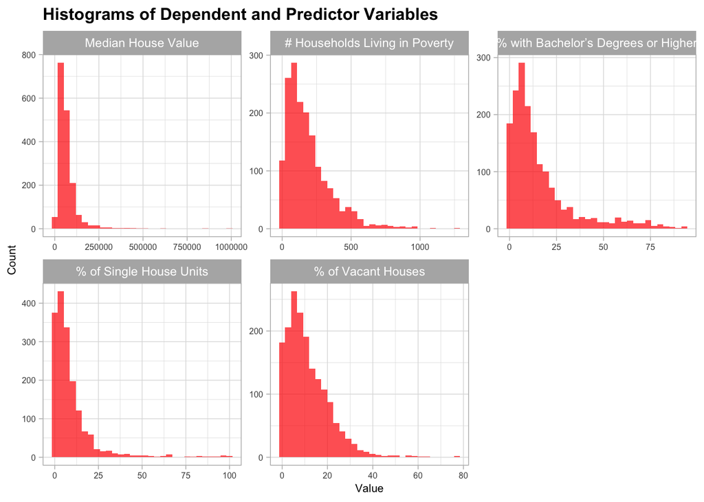

```r
reg_data %>%
  pivot_longer(cols = c("MEDHVAL", "PCTBACHMOR", "NBELPOV100", "PCTVACANT", "PCTSINGLES"),
               names_to = "Variable",
               values_to = "Value") %>%
  ggplot(aes(x = Value)) +
  geom_histogram(aes(y = ..count..), fill = "red", alpha = 0.7) +
  facet_wrap(~Variable, scales = "free", ncol = 3, labeller = as_labeller(c(
    "MEDHVAL" = "Median House Value",
    "PCTBACHMOR" = "% with Bachelor’s Degrees or Higher",
    "NBELPOV100" = "# Households Living in Poverty",
    "PCTVACANT" = "% of Vacant Houses",
    "PCTSINGLES" = "% of Single House Units"
  ))) +
  labs(x = "Value", y = "Count", title = "Histograms of Dependent and Predictor Variables") +
  theme_light() +
  theme(plot.subtitle = element_text(size = 9,face = "italic"),
        plot.title = element_text(size = 12, face = "bold"),
        axis.text.x=element_text(size=6),
        axis.text.y=element_text(size=6),
        axis.title=element_text(size=8))
```

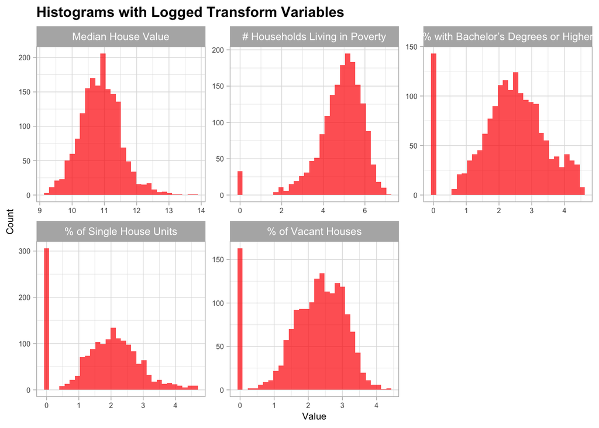

```r
# histograms of the logged variables
reg_data %>%
  pivot_longer(cols = c("LNMEDHVAL", "LNPCBACHMORE", "LNNBELPOV100", "LNPCTVACANT", "LNPCTSINGLES"),
               names_to = "Variable",
               values_to = "Value") %>%
  ggplot(aes(x = Value)) +
  geom_histogram(aes(y = ..count..), fill = "red", alpha = 0.7) +
  facet_wrap(~Variable, scales = "free", ncol = 3, labeller = as_labeller(c(
    "LNMEDHVAL" = "Median House Value",
    "LNPCBACHMORE" = "% with Bachelor’s Degrees or Higher",
    "LNNBELPOV100" = "# Households Living in Poverty",
    "LNPCTVACANT" = "% of Vacant Houses",
    "LNPCTSINGLES" = "% of Single House Units"
  ))) +
  labs(x = "Value", y = "Count", title = "Histograms with Logged Transform Variables") +
  theme_light() +
  theme(plot.subtitle = element_text(size = 9,face = "italic"),
        plot.title = element_text(size = 12, face = "bold"),
        axis.text.x=element_text(size=6),
        axis.text.y=element_text(size=6),
        axis.title=element_text(size=8))
```

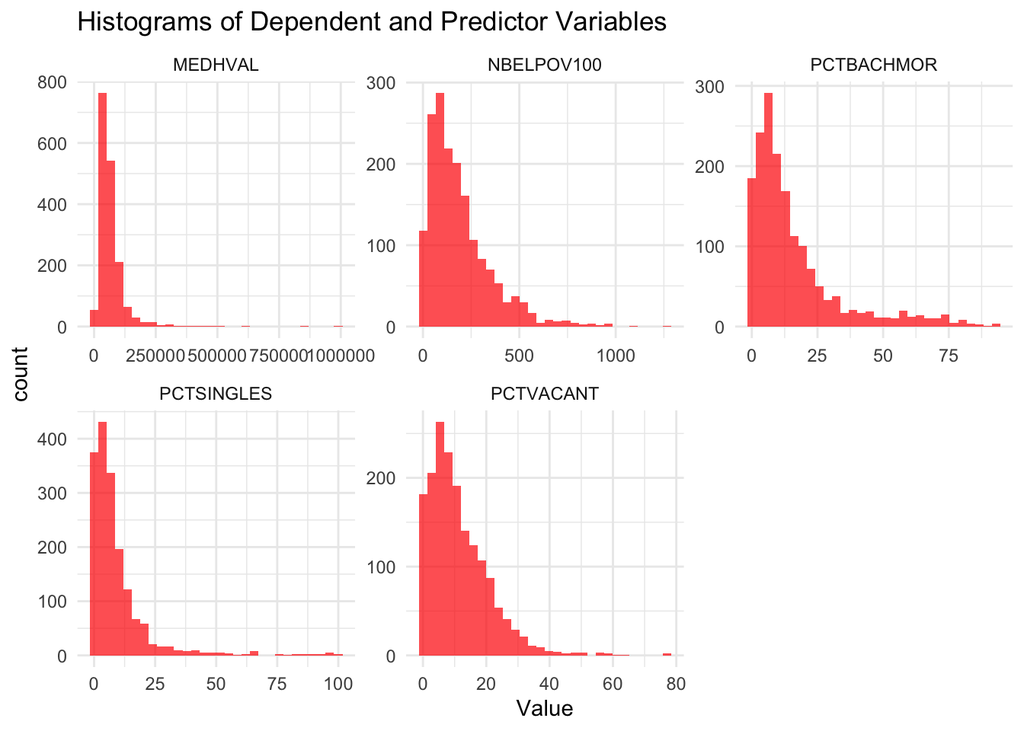

```r
# Reshape data to long format
reg_data %>%
  dplyr::select(MEDHVAL, PCTBACHMOR, NBELPOV100, PCTVACANT, PCTSINGLES) %>%
  gather(Variable, Value) %>%
  ggplot(aes(x = Value)) +
  geom_histogram(aes(y = ..count..), fill = "red", alpha = 0.7) +
  #stat_cor(label.y = 2000000) +
  theme_light() +
     facet_wrap(~Variable, scales = "free", ncol = 3) +
     labs(title = "Histograms of Dependent and Predictor Variables") +
     theme_minimal()
```

```r
names(reg_data)
```

```
##  [1] "POLY_ID"      "AREAKEY"      "MEDHVAL"      "PCTBACHMOR"   "MEDHHINC"
##  [6] "PCTVACANT"    "PCTSINGLES"   "NBELPOV100"   "LNMEDHVAL"    "LNPCBACHMORE"
## [11] "LNNBELPOV100" "LNPCTVACANT"  "LNPCTSINGLES"
```

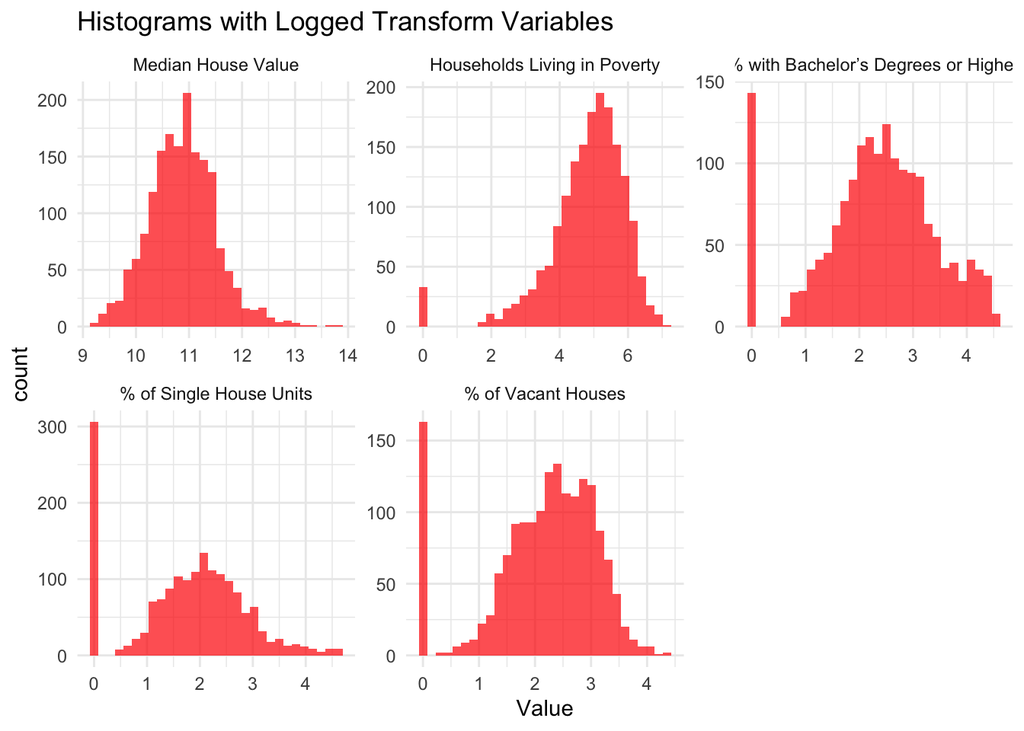

```r
reg_data %>%
  dplyr::select(LNMEDHVAL, LNPCBACHMORE ,LNNBELPOV100 , LNPCTVACANT, LNPCTSINGLES) %>%
  gather(Variable, Value) %>%
  ggplot(aes(x = Value)) +
  geom_histogram(aes(y = ..count..), fill = "red", alpha = 0.7) +
  #stat_cor(label.y = 2000000) +
  theme_light() +
     facet_wrap(~Variable, scales = "free", ncol = 3,
                 labeller = as_labeller(c(
    "LNMEDHVAL"= "Median House Value",
    "LNPCBACHMORE" = "% with Bachelor’s Degrees or Higher",
    "LNNBELPOV100" = "Households Living in Poverty",
    "LNPCTVACANT" = "% of Vacant Houses",
    "LNPCTSINGLES" = "% of Single House Units"))) +
     labs(title = "Histograms with Logged Transform Variables") +
     theme_minimal()
```

### c. Look at whether the relationship between the dependent variable and each of the predictors is linear.

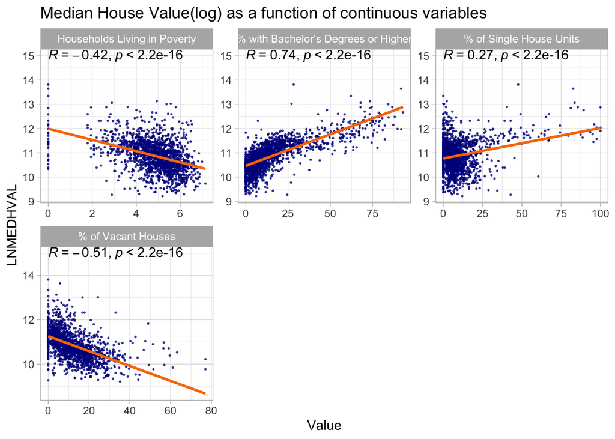

```r
reg_data %>%
   dplyr::select( LNMEDHVAL, PCTBACHMOR ,LNNBELPOV100 , PCTVACANT, PCTSINGLES) %>%
  gather(Variable, Value, -LNMEDHVAL) %>%
   ggplot(aes(Value, LNMEDHVAL)) +
     geom_point(size = .3, color = "darkblue", alpha = 0.7) +
  stat_cor(label.y = 15) +
  geom_smooth(method = "lm", se=F, colour = "#FA7800") +
     facet_wrap(~Variable, ncol = 3, scales = "free",
                labeller = as_labeller(c(
    "LNMEDHVAL"= "Median House Value",
    "PCTBACHMOR" = "% with Bachelor’s Degrees or Higher",
    "LNNBELPOV100" = "Households Living in Poverty",
    "PCTVACANT" = "% of Vacant Houses",
    "PCTSINGLES" = "% of Single House Units"))) +

     theme_light() +
       labs(title = "Median House Value(log) as a function of continuous variables")
```

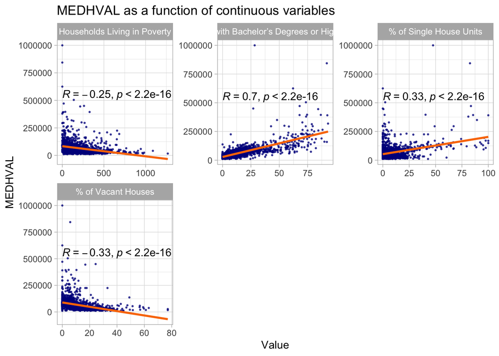

```r
reg_data %>%
  dplyr::select(MEDHVAL, PCTBACHMOR, NBELPOV100, PCTVACANT, PCTSINGLES) %>%
  gather(Variable, Value, -MEDHVAL) %>%
   ggplot(aes(Value, MEDHVAL)) +
  geom_point(color = "darkblue", alpha = 0.7, size = 0.4) +
  stat_cor(label.y = 550000) +
  geom_smooth(method = "lm", se=F, colour = "#FA7800") +
     facet_wrap(~Variable, ncol = 3, scales = "free",
                labeller = as_labeller(c(
    "PCTBACHMOR" = "% with Bachelor’s Degrees or Higher",
    "NBELPOV100" = "Households Living in Poverty",
    "PCTVACANT" = "% of Vacant Houses",
    "PCTSINGLES" = "% of Single House Units"))) +
        theme_light() +
     labs(title = "MEDHVAL as a function of continuous variables")
```

### d. Look at the Pearson correlations between all the predictors you will be including in your model, listed below.

```r
# Calculate Pearson correlation coefficients
correlations <- reg_data %>%
  summarise(
    Correlation_BachMore = cor(MEDHVAL, LNPCBACHMORE, use = "complete.obs"),
    Correlation_HouseholdsPoverty = cor(MEDHVAL, LNNBELPOV100, use = "complete.obs"),
    Correlation_VacantHouses = cor(MEDHVAL, LNPCTVACANT, use = "complete.obs"),
    Correlation_SingleUnits = cor(MEDHVAL, LNPCTSINGLES, use = "complete.obs")
  )

# Display the results
print(correlations)
```

```
##   Correlation_BachMore Correlation_HouseholdsPoverty Correlation_VacantHouses
## 1            0.5641648                    -0.3748807               -0.3569778
##   Correlation_SingleUnits
## 1               0.1200889
```

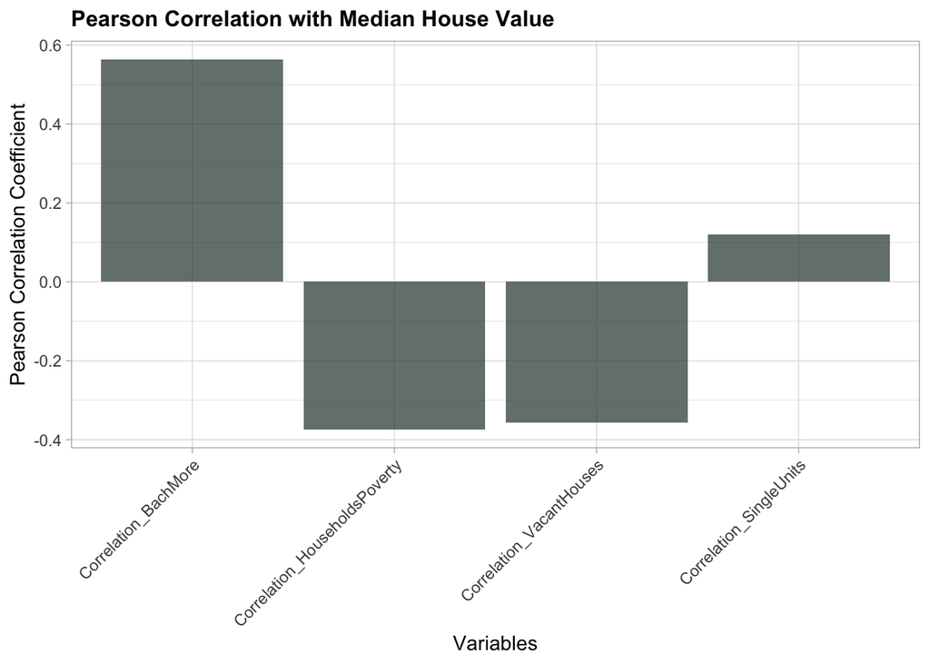

```r
library(ggplot2)
library(reshape2)
# Melt the correlation data for visualization
correlations_melted <- melt(correlations)
# Create a bar plot for correlations
ggplot(correlations_melted, aes(x = variable, y = value)) +
  geom_bar(stat = "identity", fill = "#283d3b", alpha = 0.7) +
  labs(x = "Variables", y = "Pearson Correlation Coefficient", title = "Pearson Correlation with Median House Value") +
  theme_light() +
  theme(axis.text.x = element_text(angle = 45, hjust = 1),
        plot.title = element_text(size = 12, face = "bold"))
```

```r
cor.test(reg_data$MEDHHINC, reg_data$PCTVACANT, method=("pearson"))
```

```
##
##  Pearson's product-moment correlation
##
## data:  reg_data$MEDHHINC and reg_data$PCTVACANT
## t = -19.311, df = 1718, p-value < 2.2e-16
## alternative hypothesis: true correlation is not equal to 0
## 95 percent confidence interval:
##  -0.4603983 -0.3826976
## sample estimates:
##        cor
## -0.4223235
```

```r
varibles <-
  reg_data %>%
  dplyr::select(PCTVACANT, PCTSINGLES, PCTBACHMOR, LNNBELPOV100) %>% na.omit()

round(cor(varibles), 1)
```

```
##              PCTVACANT PCTSINGLES PCTBACHMOR LNNBELPOV100
## PCTVACANT          1.0       -0.2       -0.3          0.2
## PCTSINGLES        -0.2        1.0        0.2         -0.3
## PCTBACHMOR        -0.3        0.2        1.0         -0.3
## LNNBELPOV100       0.2       -0.3       -0.3          1.0
```

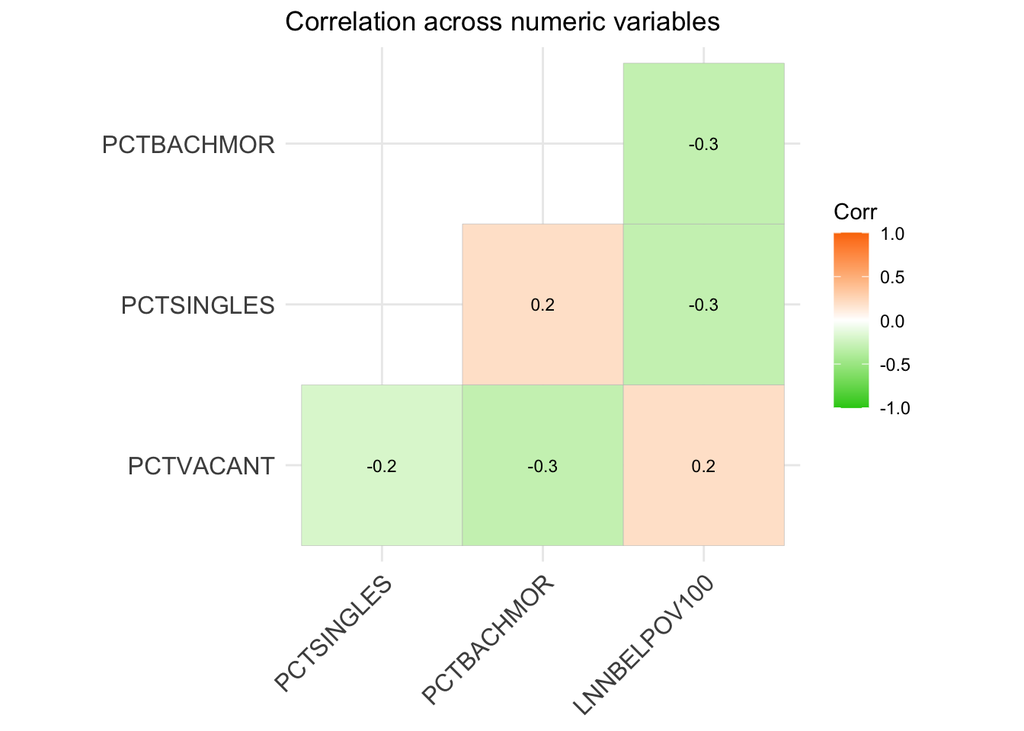

```r
 ggcorrplot(
  round(cor(varibles), 1),
  p.mat = cor_pmat(varibles),
  colors = c("#25CB10", "white", "#FA7800"),
  lab = TRUE,
  lab_size = 3,
  type="lower",
  insig = "blank") +
    labs(title = "Correlation across numeric variables")
```